# subsppLabelR_1

## Setting Up the Package

First we must install the R package before we can use it.

```r
## before 15 jan 2025
library(devtools)
devtools::install_github('kaiyaprovost/subsppLabelR',force=F)
library(subsppLabelR)
```

Let us download some data. We will use *Phainopepla nitens* as a test species: it has two subspecies that are relatively allopatric. Although the species has hundreds of thousands of points, for now we will only download 2000.

```r
spp = "Phainopepla nitens"
subsppList = c("lepida","nitens")
pointLimit=2000
dbToQuery=c("gbif")

print("Downloading species occurrences")
```

```
## [1] "Downloading species occurrences"
```

```r
listFromSubspeciesOcc = subsppLabelR::subspeciesOccQuery(
  spp = spp,
  subsppList = subsppList,
  pointLimit = pointLimit,
  dbToQuery = dbToQuery
)
```

```
## [1] "Getting Species:  Phainopepla nitens"
## [1] "     Getting Subspecies:  lepida"
## [1] "     Getting Subspecies:  nitens"
## Searched: gbif
## Occurrences - Found: 545,712, Returned: 2,000
## Search type: Scientific
##   gbif: Phainopepla nitens (2000)
## $lepida
## Searched: gbif
## Occurrences - Found: 1,757, Returned: 1,757
## Search type: Scientific
##   gbif: Phainopepla nitens lepida (1757)
##
## $nitens
## Searched: gbif
## Occurrences - Found: 67, Returned: 67
## Search type: Scientific
##   gbif: Phainopepla nitens nitens (67)
```

Now we have returned an object with 2000 occurrences that are not labeled, ~1700 that are labeled as *lepida*, and ~70 labeled as *nitens*. Let’s do the labeling procedure.

```r
## label the data by subspecies
print("Labeling data by subspecies")
```

```
## [1] "Labeling data by subspecies"
```

```r
labeledLoc = subsppLabelR::labelSubspecies(subsppOccList = listFromSubspeciesOcc)
```

```
## [1] "lepida"
## [1] "nitens"
```

```r
labeledLoc = labeledLoc[!(is.na(labeledLoc$longitude)),]
labeledLoc = labeledLoc[!(is.na(labeledLoc$latitude)),]

head(labeledLoc)
```

```
##                                  name longitude latitude prov       date
## 1 Phainopepla nitens (Swainson, 1838) -117.8752 34.03867 gbif 2025-01-01
## 2 Phainopepla nitens (Swainson, 1838) -118.1297 34.20482 gbif 2025-01-01
## 3 Phainopepla nitens (Swainson, 1838) -116.3858 33.70131 gbif 2025-01-01
## 4 Phainopepla nitens (Swainson, 1838) -117.1825 34.05553 gbif 2025-01-01
## 5 Phainopepla nitens (Swainson, 1838) -117.0941 32.55388 gbif 2025-01-01
## 6 Phainopepla nitens (Swainson, 1838) -118.4231 34.03721 gbif 2025-01-01
##          key subspecies
## 1 5007745493    unknown
## 2 5007726941    unknown
## 3 5062944356    unknown
## 4 5007672481    unknown
## 5 5007257589    unknown
## 6 5007745594    unknown
```

This has added a column to the data with the occurrences labeled by subspecies. Lets plot these data. First though, we need a raster layer to plot against. We can either import a raster as “bgLayer”, or we can create one from the *Phainopepla* data. For this example we will create a raster layer. We will then plot the data.

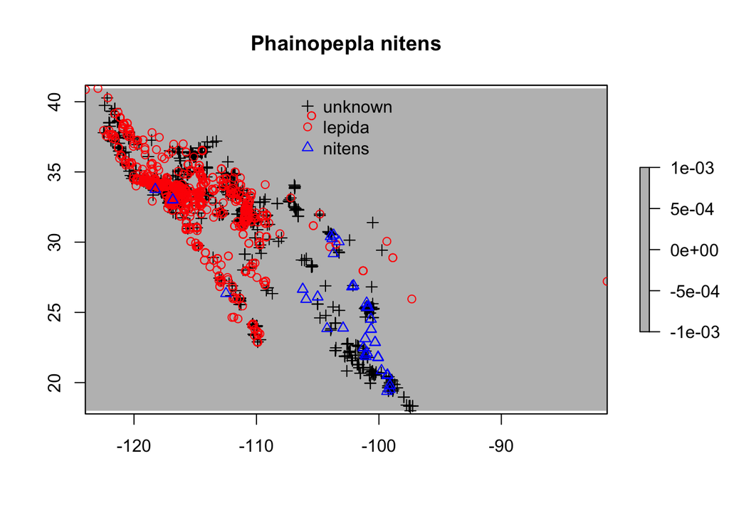

```r
max_long = max(labeledLoc$longitude,na.rm=T)
min_long = min(labeledLoc$longitude,na.rm=T)
max_lat = max(labeledLoc$latitude,na.rm=T)
min_lat = min(labeledLoc$latitude,na.rm=T)
palette(c("red","blue","black","lightblue","cyan","pink","magenta","purple","brown"))

ext = raster::extent(c(min_long,max_long,min_lat,max_lat))
bgLayer = raster::raster(ext=ext,nrow=100,ncol=100,vals=0)

subsppNames = unique(labeledLoc$subspecies)

raster::plot(bgLayer,
             col = "grey",
             colNA = "darkgrey",
             main = spp)
points(labeledLoc$longitude,
       labeledLoc$latitude,
       col = as.numeric(as.factor(labeledLoc$subspecies)),
       pch = as.numeric(as.factor(labeledLoc$subspecies)))
legend(
  "top",
  legend = as.factor(unique(labeledLoc$subspecies)),
  bty = "n",
  col = as.numeric(as.factor(unique(labeledLoc$subspecies))),
  pch = as.numeric(as.factor(unique(labeledLoc$subspecies)))
)
```

As you can see with this example, there is are outliers that is far east from the rest of the distribution. Otherwise, the red and blue dots (which are labeled subspecies) appear to roughly correspond with the known distributions.

Setting epsilon to be a higher value will remove more anomalies. Setting it to a lower value will remove fewer anomalies. You will likely need to tune your epsilon value. One way to do this is by examining the data in labeledLoc to see what sort of cutoffs there are.

For example, we know that there are some *nitens* points that are very far west. What epsilon value would we need to set for this subspecies? we can examine this by using the mgdad_px() function on just *nitens* data to see what the probabilities are and what cutoff we may wish to use.

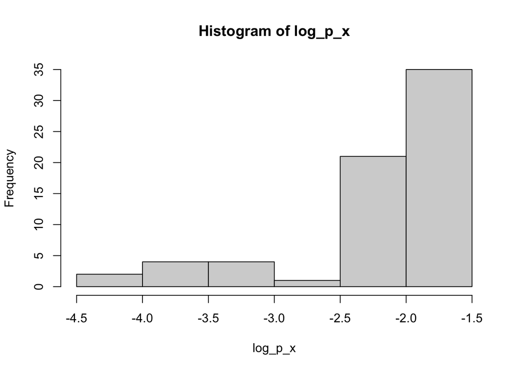

```r
p_x = subsppLabelR::mgdad_px(labeledLoc[labeledLoc$subspecies=="nitens",c("latitude","longitude")])
log_p_x = log10(p_x)
hist(log_p_x)
```

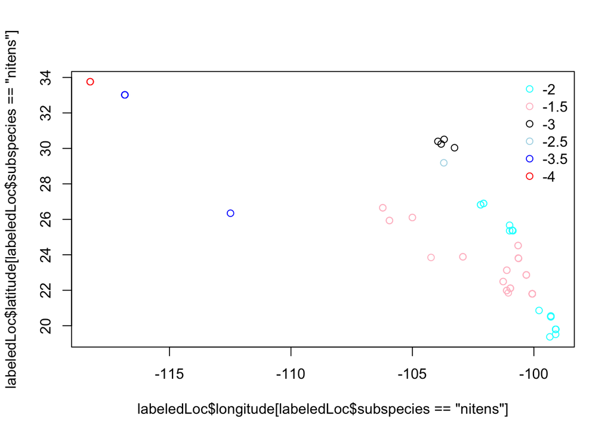

```r
log_p_x_cutoffs = ceiling(log_p_x*2)/2
plot(labeledLoc$longitude[labeledLoc$subspecies=="nitens"],
     labeledLoc$latitude[labeledLoc$subspecies=="nitens"],
     col=as.factor(log_p_x_cutoffs))
legend(
  "topright",
  legend = as.factor(unique(log_p_x_cutoffs)),
  pch = 1,
  bty = "n",
  col = as.factor(unique(log_p_x_cutoffs))
)
```

It seems that an epsilon value of 10^-3.5 would suffice to get rid of those two west points, though it will also remove some of the others. We will not examine values for other subspecies or the full species distribution here, but I recommend you do so on your own data.

Lets do anomaly detection now to remove the species-wide outliers and then update the dataset. In this case, for the full species an epsilon value of 10^-6 is more appropriate, so we will use two epsilons.

NOTE: your epsilon cutoff values can change when you remove certain points. If you decide to iteratively remove outliers, keep this in mind.

```r
print("Starting anomaly detection for whole species")
```

```
## [1] "Starting anomaly detection for whole species"
```

```r
list_of_anomalies = c()
spp_epsilon = 10^-6

anomalies = subsppLabelR::detectSpatialOutliers(localities = labeledLoc, epsilon = spp_epsilon)

list_of_anomalies = c(list_of_anomalies, anomalies)

list_of_anomalies_names = names(list_of_anomalies)
rows_purged = sort(unique(list_of_anomalies_names))

print("Starting anomaly detection for each subspecies")
```

```
## [1] "Starting anomaly detection for each subspecies"
```

```r
list_of_anomalies_sub = c()
subspp_epsilon = 10^-3.5

for (i in 1:length(c(subsppNames))) {
  name = subsppNames[[i]]
  if (name != "unknown") {
    #print(name)
    subset = labeledLoc[labeledLoc$subspecies == name,]
    #print(nrow(subset))
    anomalies = subsppLabelR::detectSpatialOutliers(localities = subset, epsilon = subspp_epsilon)
  }
  #print(length(anomalies))
  list_of_anomalies_sub = c(list_of_anomalies_sub, anomalies)

}
list_of_anomalies_sub_names = names(list_of_anomalies_sub)
rows_purged_sub = sort(unique(as.integer(list_of_anomalies_sub_names)))

rows_purged = sort(unique(c(rows_purged,rows_purged_sub)))
```

Let’s visualize these anomalies.

```r
print(paste(
  "Removing",
  length(rows_purged),
  "of",
  length(labeledLoc[, 1]),
  "detected anomalies"
))
```

```
## [1] "Removing 77 of 3824 detected anomalies"
```

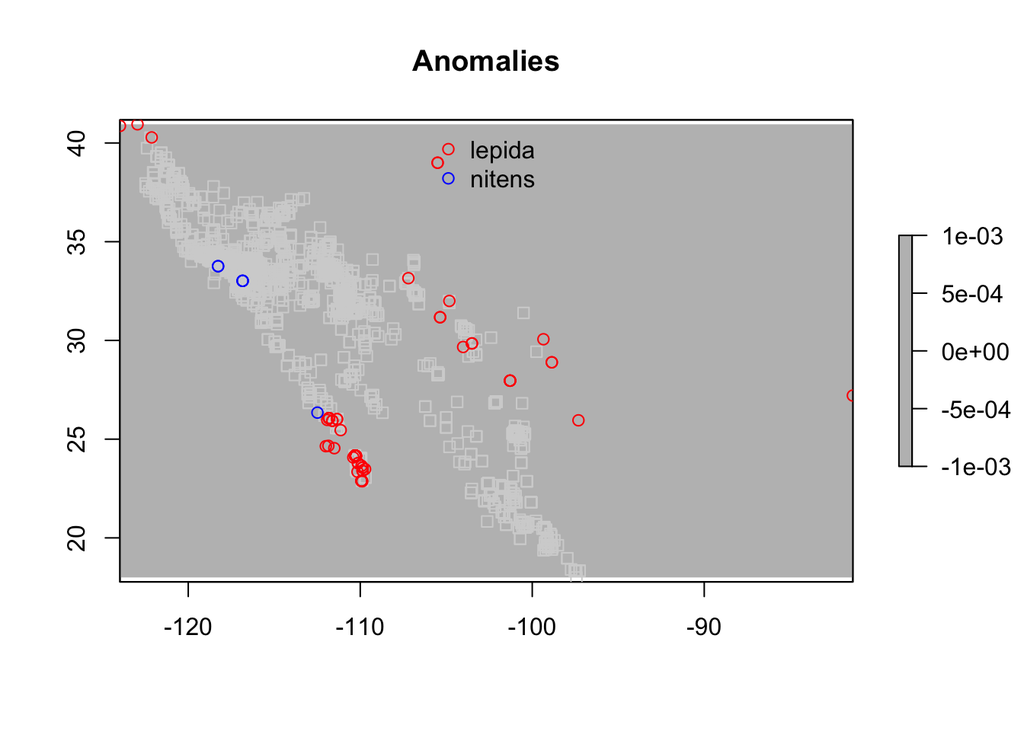

```r
removed = labeledLoc[(rownames(labeledLoc) %in% rows_purged),]
labeledLoc = labeledLoc[!(rownames(labeledLoc) %in% rows_purged),]
## set up factors for removed
removed$subspecies = as.factor(removed$subspecies)
levels(removed$subspecies) = levels(as.factor(labeledLoc$subspecies))

raster::plot(
  bgLayer,
  col = "grey",
  colNA = "darkgrey",
  main = paste("Anomalies")
)
points(labeledLoc$longitude,
       labeledLoc$latitude,
       col = "lightgrey",
       pch = 0)
points(removed$longitude,
       removed$latitude,
       col = as.factor(removed$subspecies))
legend(
  "top",
  legend = as.factor(unique(removed$subspecies)),
  pch = 1,
  bty = "n",
  col = as.factor(unique(removed$subspecies))
)
```

These indeed look like outliers, though our subspecies cutoff might be too high for *lepida*. We shall leave the *lepida* as is for now, to be more conservative with our estimate.

We also will do a quick clean up to make sure that none of the subspecies are now only represented by a single individual, and also to alter the raster file so that it is no longer so wide.

```r
## removing single individual subspecies
print("Removing single-individual subspecies")
```

```
## [1] "Removing single-individual subspecies"
```

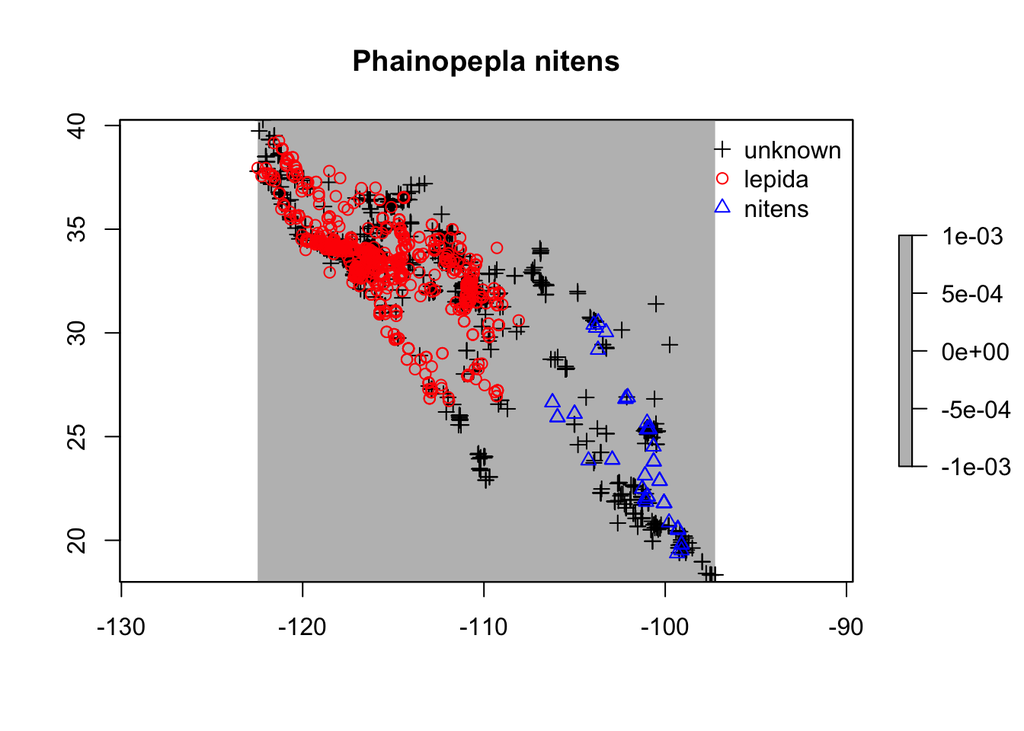

```r
for (sub in unique(labeledLoc$subspecies)) {
  #print(sub)
  rows = (nrow(labeledLoc[labeledLoc$subspecies == sub,]))
  if (rows <= 1) {
    print(sub)
    labeledLoc = labeledLoc[labeledLoc$subspecies != sub,]
  }
}
subsppNames = unique(labeledLoc$subspecies)

max_long = max(labeledLoc$longitude,na.rm=T)
min_long = min(labeledLoc$longitude,na.rm=T)
max_lat = max(labeledLoc$latitude,na.rm=T)
min_lat = min(labeledLoc$latitude,na.rm=T)
palette(c("red","blue","black","lightblue","cyan"))

ext = raster::extent(c(min_long,max_long,min_lat,max_lat))
bgLayer = raster::raster(ext=ext,nrow=100,ncol=100,vals=0)
raster::plot(bgLayer,
             col = "grey",
             colNA = "darkgrey",
             main = spp)
points(labeledLoc$longitude,
       labeledLoc$latitude,
       col = as.numeric(as.factor(labeledLoc$subspecies)),
       pch = as.numeric(as.factor(labeledLoc$subspecies)))
legend(
  "topright",
  legend = as.factor(unique(labeledLoc$subspecies)),
  bty = "n",
  col = as.numeric(as.factor(unique(labeledLoc$subspecies))),
  pch = as.numeric(as.factor(unique(labeledLoc$subspecies)))
)
```

Now let us plot the density maps for the species. We will only retain the top 5% most dense points (the 95th percentile) for each subspecies.

```r
xmax = max_long
xmin = min_long
ymax = max_lat
ymin = min_lat
quant=0.95

#total_range = bgLayer
#raster::values(total_range)[!is.na(raster::values(bgLayer))] = NA

print("Building species kernel density maps")
```

```
## [1] "Building species kernel density maps"
```

```r
densityRasters = lapply(subsppNames, function(subspp) {
  print(subspp)
  locs = labeledLoc[labeledLoc$subspecies == subspp,]
  dens = subsppLabelR::subspeciesDensityMap(
    localities = locs,
    quant = quant,
    xmin = xmin,
    xmax = xmax,
    ymin = ymin,
    ymax = ymax,
    total_range= bgLayer,
    outputDir = getwd(),
    spp = spp,
    subspp = subspp
  )
  if (is.null(dens)) {
    dens = NA
  }

  if ((length((raster::unique(dens,na.last=NA)))) == 0) {
    dens = NA
  }

  names(dens) = subspp
  return(dens)
})
```

```
## [1] "unknown"
## [1] "rescaling"
```

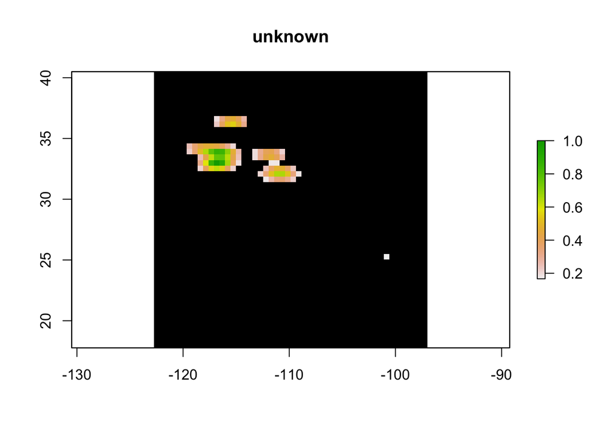

```
## [1] "lepida"
## [1] "rescaling"
```

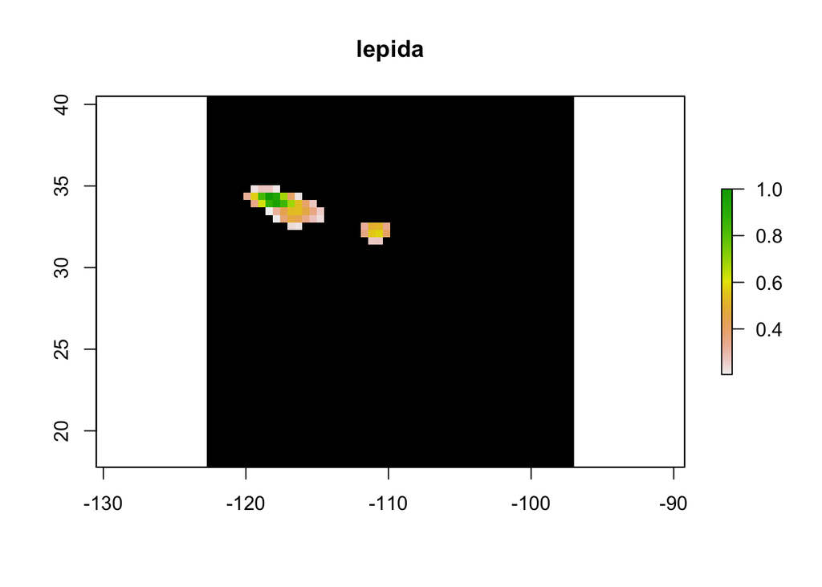

```
## [1] "nitens"
## [1] "rescaling"
```

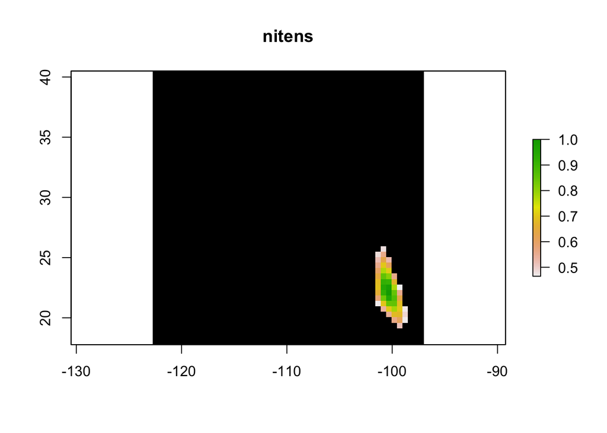

```r
#print("done density")
names(densityRasters) = subsppNames

## remove failed ones
densityRasters = densityRasters[!(is.na(densityRasters))]
subsppNames = names(densityRasters)
```

Lets plot these data.

```
## [1] 1
```

```
## [1] 2
```

```
## [1] 3
```

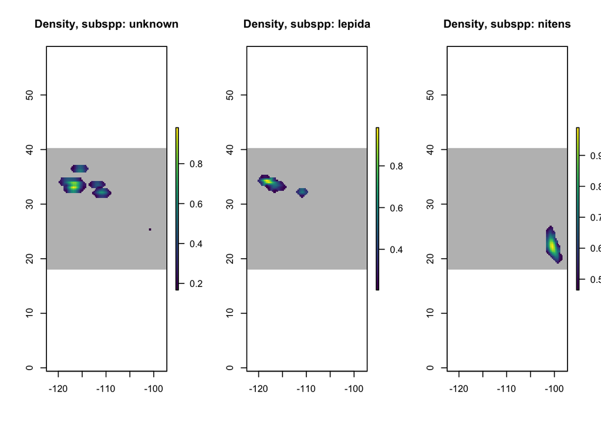

```r
par(mfrow=c(1,3))
for (i in 1:length(densityRasters)) {
  print(i)
  name = names(densityRasters)[[i]]
  raster::plot(
    bgLayer,
    col = "grey",
    colNA = "darkgrey",
    legend=F,
    main = paste("Density, subspp:", name)
  )
  raster::plot(densityRasters[[i]],
               add = T,
               col = viridis::viridis(99))
}
```

Hm. The *lepida* looks like it is a little gappy. Let’s look at density cutoffs of 5%, 10%, and 15% (the 95th, 90th, and 85th percentile, respectively).

```r
quant = 0.90

print("Building species kernel density maps -- top 10 %")
```

```
## [1] "Building species kernel density maps -- top 10 %"
```

```r
densityRasters_10 = lapply(subsppNames, function(subspp) {
  print(subspp)
  locs = labeledLoc[labeledLoc$subspecies == subspp,]
  dens = subsppLabelR::subspeciesDensityMap(
    localities = locs,
    quant = quant,
    xmin = xmin,
    xmax = xmax,
    ymin = ymin,
    ymax = ymax,
    total_range= bgLayer,
    outputDir = getwd(),
    spp = spp,
    subspp = subspp
  )
  if (is.null(dens)) {
    dens = NA
  }

  if ((length((raster::unique(dens,na.last=NA)))) == 0) {
    dens = NA
  }

  names(dens) = subspp
  return(dens)
})
```

```
## [1] "unknown"
## [1] "rescaling"
```

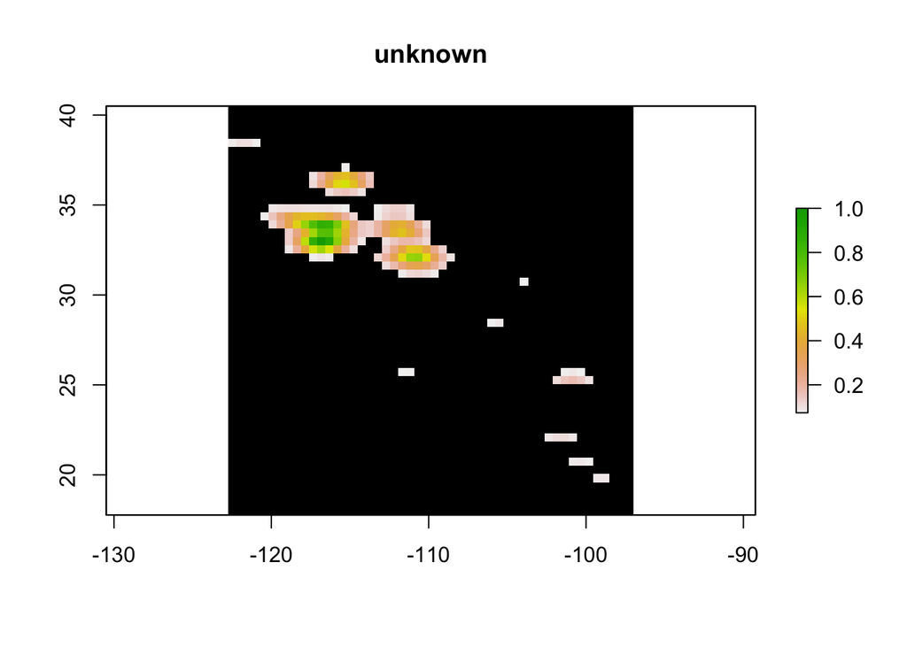

```
## [1] "lepida"
## [1] "rescaling"
```

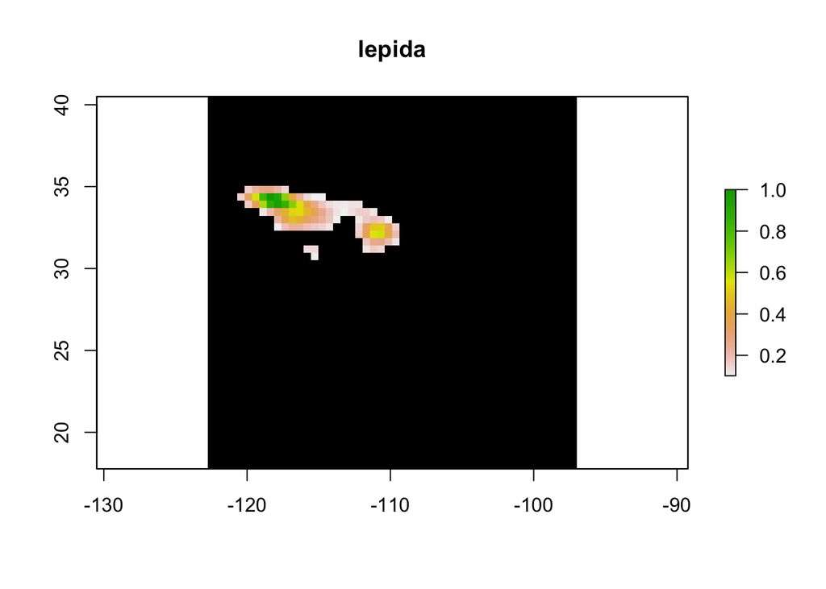

```
## [1] "nitens"
## [1] "rescaling"
```

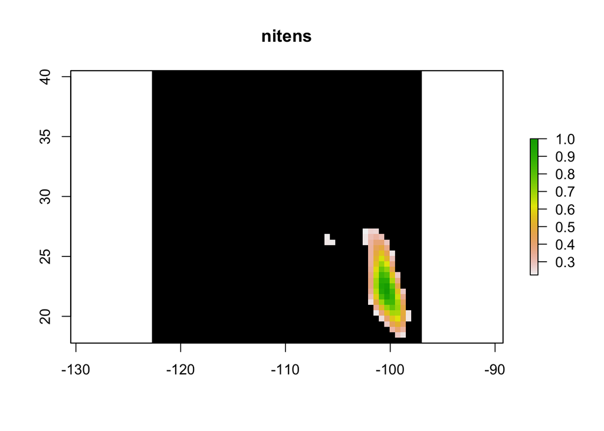

```r
#print("done density")
names(densityRasters_10) = subsppNames

## remove failed ones
densityRasters_10 = densityRasters_10[!(is.na(densityRasters_10))]
subsppNames = names(densityRasters_10)


quant=0.85

print("Building species kernel density maps -- top 15 %")
```

```
## [1] "Building species kernel density maps -- top 15 %"
```

```r
densityRasters_15 = lapply(subsppNames, function(subspp) {
  print(subspp)
  locs = labeledLoc[labeledLoc$subspecies == subspp,]
  dens = subsppLabelR::subspeciesDensityMap(
    localities = locs,
    quant = quant,
    xmin = xmin,
    xmax = xmax,
    ymin = ymin,
    ymax = ymax,
    total_range= bgLayer,
    outputDir = getwd(),
    spp = spp,
    subspp = subspp
  )
  if (is.null(dens)) {
    dens = NA
  }

  if ((length((raster::unique(dens,na.last=NA)))) == 0) {
    dens = NA
  }

  names(dens) = subspp
  return(dens)
})
```

```
## [1] "unknown"
## [1] "rescaling"
```

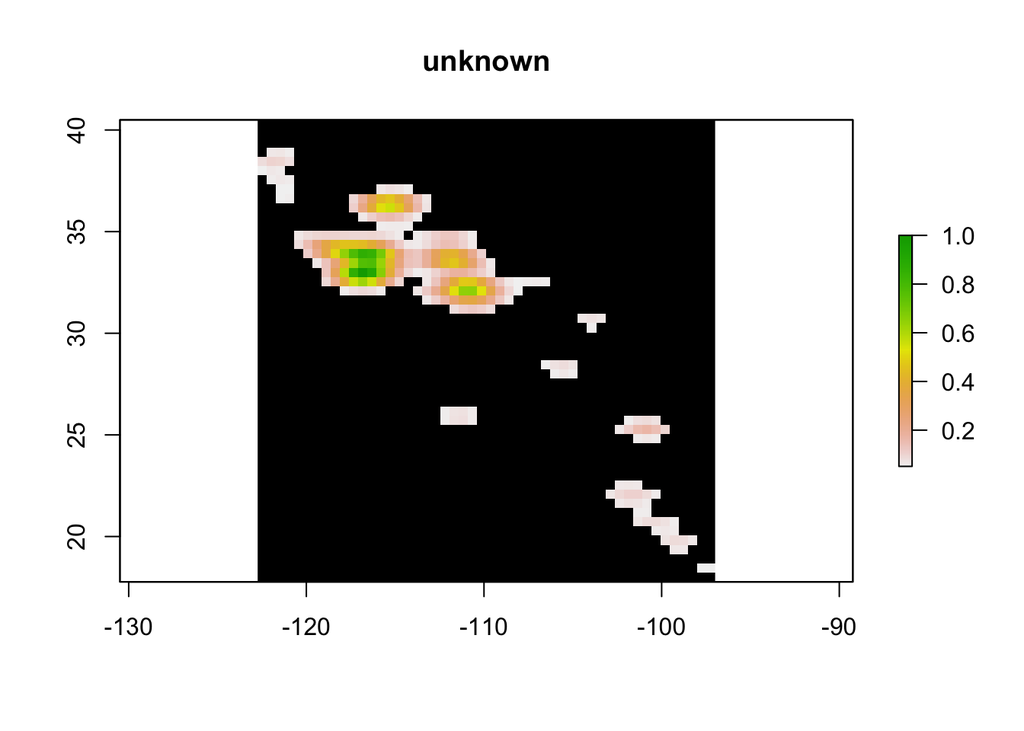

```
## [1] "lepida"
## [1] "rescaling"
```

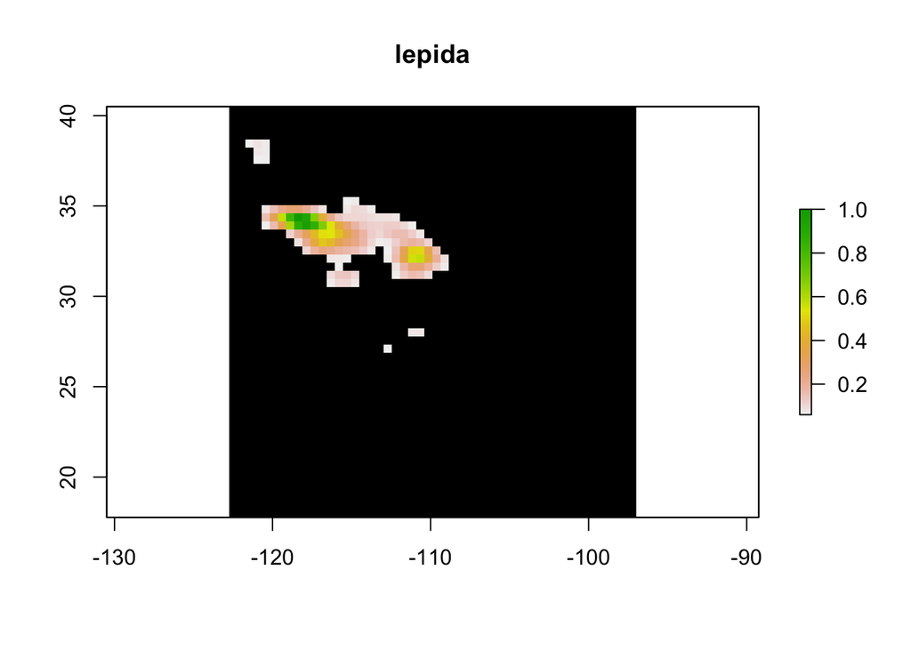

```
## [1] "nitens"
## [1] "rescaling"
```

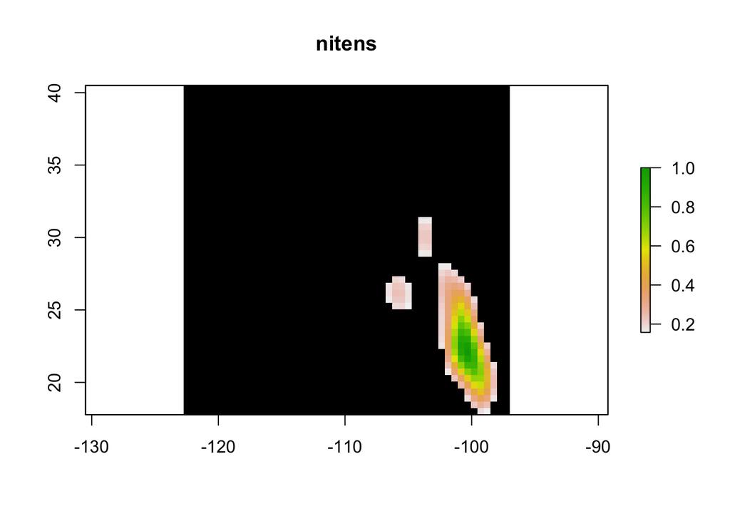

```r
#print("done density")
names(densityRasters_15) = subsppNames

## remove failed ones
densityRasters_15 = densityRasters_15[!(is.na(densityRasters_15))]
subsppNames = names(densityRasters_15)

par(mfrow=c(3,3),mar=c(4,4,4,4))
for (i in 1:length(densityRasters)) {
  print(i)
  name = names(densityRasters)[[i]]
  raster::plot(
    bgLayer,
    col = "grey",
    colNA = "darkgrey",
    legend=F,
    main = paste("Density for 5%, subspp:", name)
  )
  raster::plot(densityRasters[[i]],
               add = T,
               col = viridis::viridis(99))
}
```

```
## [1] 1
```

```
## [1] 2
```

```
## [1] 3
```

```r
for (i in 1:length(densityRasters_10)) {
  print(i)
  name = names(densityRasters_10)[[i]]
  raster::plot(
    bgLayer,
    col = "grey",
    colNA = "darkgrey",
    legend=F,
    main = paste("Density for 10%, subspp:", name)
  )
  raster::plot(densityRasters_10[[i]],
               add = T,
               col = viridis::viridis(99))
}
```

```
## [1] 1
```

```
## [1] 2
```

```
## [1] 3
```

```
## [1] 1
```

```
## [1] 2
```

```
## [1] 3
```

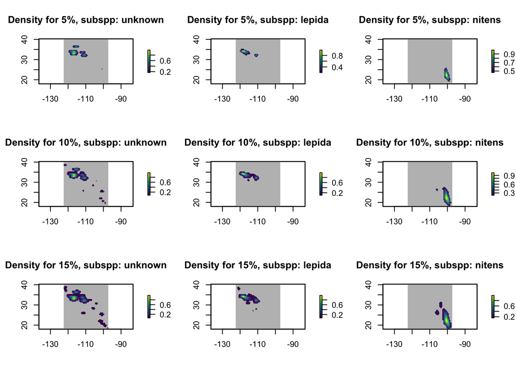

```r
for (i in 1:length(densityRasters_15)) {
  print(i)
  name = names(densityRasters_15)[[i]]
  raster::plot(
    bgLayer,
    col = "grey",
    colNA = "darkgrey",
    legend=F,
    main = paste("Density for 15%, subspp:", name)
  )
  raster::plot(densityRasters_15[[i]],
               add = T,
               col = viridis::viridis(99))
}
```

Now we can see where the bulk of the data are found for these ranges. Most of the unknown samples we downloaded appear to be in subspecies *lepida*. Comparing the plots shows us how choosing cutoffs can impact our downstream analyses. We will continue for now with the top 10%, as it seems to connect the bulk of the *lepida* samples without adding too many extra bits.

Next let us remove any overlaps that exist in our raster data. For this particular configuration of the data, there are no overlaps to be seen. On this dataset, we start finding overlaps around the 75% density cutoff.

```r
print("Removing overlapping raster sections from density map")
```

```
## [1] "Removing overlapping raster sections from density map"
```

```r
## move pairwise over densityRasters, but do not include unknown which is in position 1
validRasters = densityRasters_10
for (rasterA_i in 2:length(validRasters)) {
  for(rasterB_i in 2:length(validRasters)) {
    if (rasterA_i > rasterB_i) {
      densA = validRasters[[rasterA_i]]
      densB = validRasters[[rasterB_i]]
      validRasterList = densityRasterRemoveIntersection(densA=densA,densB=densB,verbose=T)
      validRasters[[rasterA_i]] = validRasterList[[1]]
      validRasters[[rasterB_i]] = validRasterList[[2]]
    }
  }
}
```

```
## [1] "Calculate raster pres/abs and overlap"
## [1] "No overlaps detected! Returning original rasters."
```

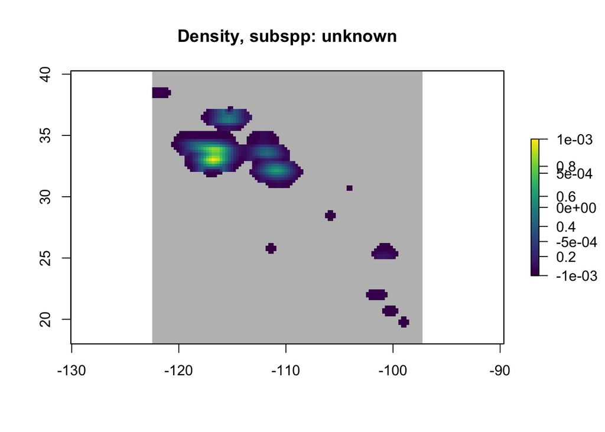

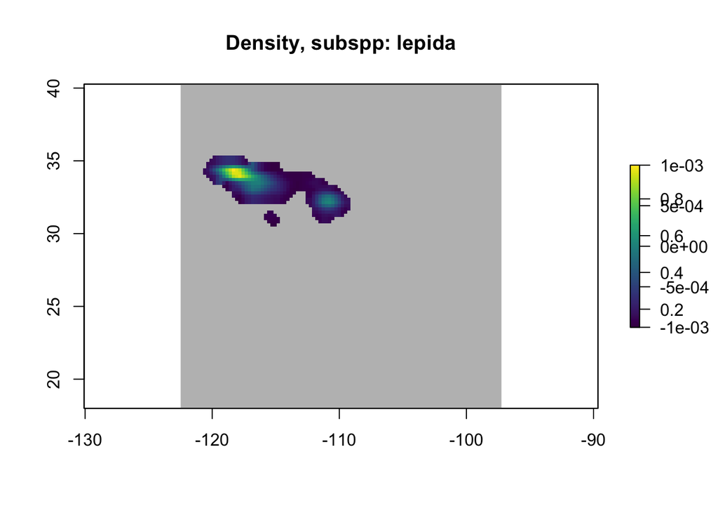

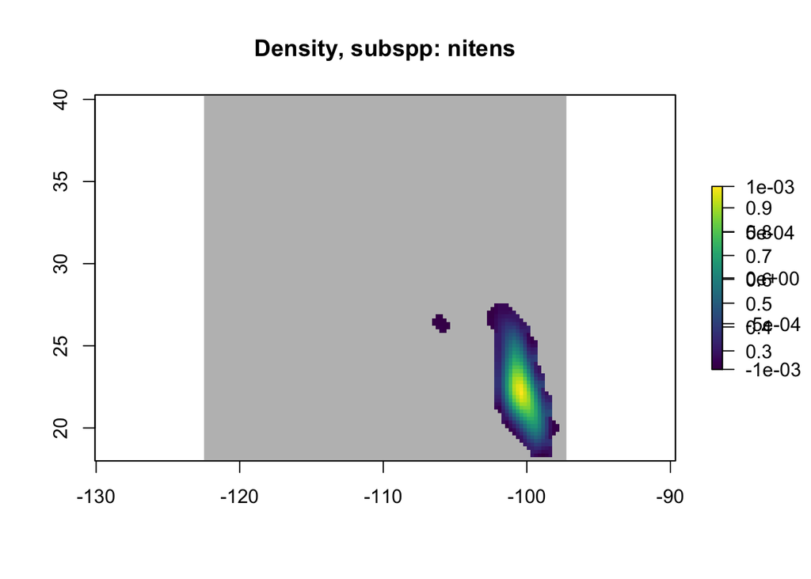

```r
for (i in 1:length(validRasters)) {
  name = names(validRasters)[[i]]
  raster::plot(
    bgLayer,
    col = "grey",
    colNA = "darkgrey",
    main = paste("Density, subspp:", name)
  )
  raster::plot(validRasters[[i]],
               add = T,
               col = viridis::viridis(99))
}
```

These rasters look good considering we are missing a lot of data from the center of the distribution. Now lets locate the unknown points relative to those rasters and do some clean up.

```r
print("Locating points relative to rasters")
```

```
## [1] "Locating points relative to rasters"
```

```r
polyLocations = labeledLoc
for (slotA in 1:length(subsppNames)) {
  if (subsppNames[[slotA]] != "unknown") {
    polyLocations = subsppLabelR::locateRasterPoints(
      test_points = polyLocations,
      rasterA = validRasters[[slotA]],
      name=subsppNames[[slotA]]
    )

  }

}

print ("Cleaning up duplicate columns")
```

```
## [1] "Cleaning up duplicate columns"
```

```r
colsToDelete = c()

#print(polyLocations)

for (colNumA in 5:length(colnames(polyLocations))) {
  for (colNumB in 6:length(colnames(polyLocations))) {
    if (colNumA < colNumB) {
      #print(paste("compare",colNumA,colNumB,sep=" "))
      if (identical(polyLocations[[colNumA]], polyLocations[[colNumB]])) {
        #print("identical, deleting")
        colsToDelete = c(colsToDelete, colNumB)
      }
    }
  }
}
if (!(is.null(colsToDelete))) {
  polyLocations = polyLocations[,-colsToDelete]
}

head(polyLocations)
```

```
##                                  name longitude latitude prov       date
## 1 Phainopepla nitens (Swainson, 1838) -117.8752 34.03867 gbif 2025-01-01
## 2 Phainopepla nitens (Swainson, 1838) -118.1297 34.20482 gbif 2025-01-01
## 3 Phainopepla nitens (Swainson, 1838) -116.3858 33.70131 gbif 2025-01-01
## 4 Phainopepla nitens (Swainson, 1838) -117.1825 34.05553 gbif 2025-01-01
## 5 Phainopepla nitens (Swainson, 1838) -117.0941 32.55388 gbif 2025-01-01
## 6 Phainopepla nitens (Swainson, 1838) -118.4231 34.03721 gbif 2025-01-01
##          key subspecies lepida nitens
## 1 5007745493    unknown      1      0
## 2 5007726941    unknown      1      0
## 3 5062944356    unknown      1      0
## 4 5007672481    unknown      1      0
## 5 5007257589    unknown      1      0
## 6 5007745594    unknown      1      0
```

Now we will label the occurrences based on those rasters and flag anything that looks suspect.

```r
print("Matching subspecies")
```

```
## [1] "Matching subspecies"
```

```r
checked = subsppLabelR::subspeciesMatchChecker(locfile = polyLocations, subsppNames =
                                                 subsppNames)
```

```
## [1] 5
## [1] 6
## [1] "NONE ASSIGNED:"
## [1] "key"
## [1] 7
## [1] "NONE ASSIGNED:"
## [1] "subspecies"
## [1] 8
## [1] 9
```

```r
loc_suspect = checked$suspect
loc_good = checked$good
```

And the final output:

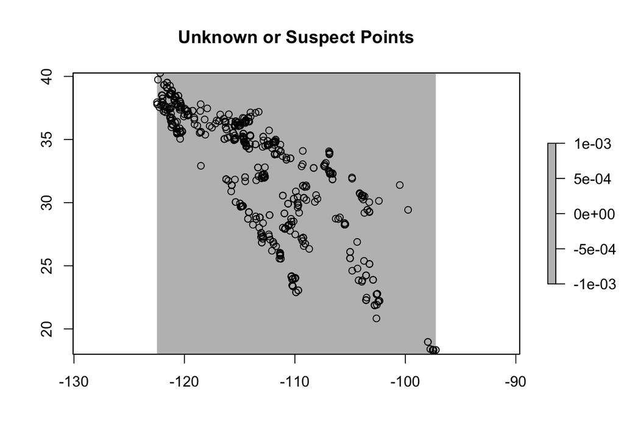

```r
par(mfrow=c(1,1))

raster::plot(
  bgLayer,
  col = "grey",
  colNA = "darkgrey",
  main = "Unknown or Suspect Points"
)
points(loc_suspect$longitude,loc_suspect$latitude)
```

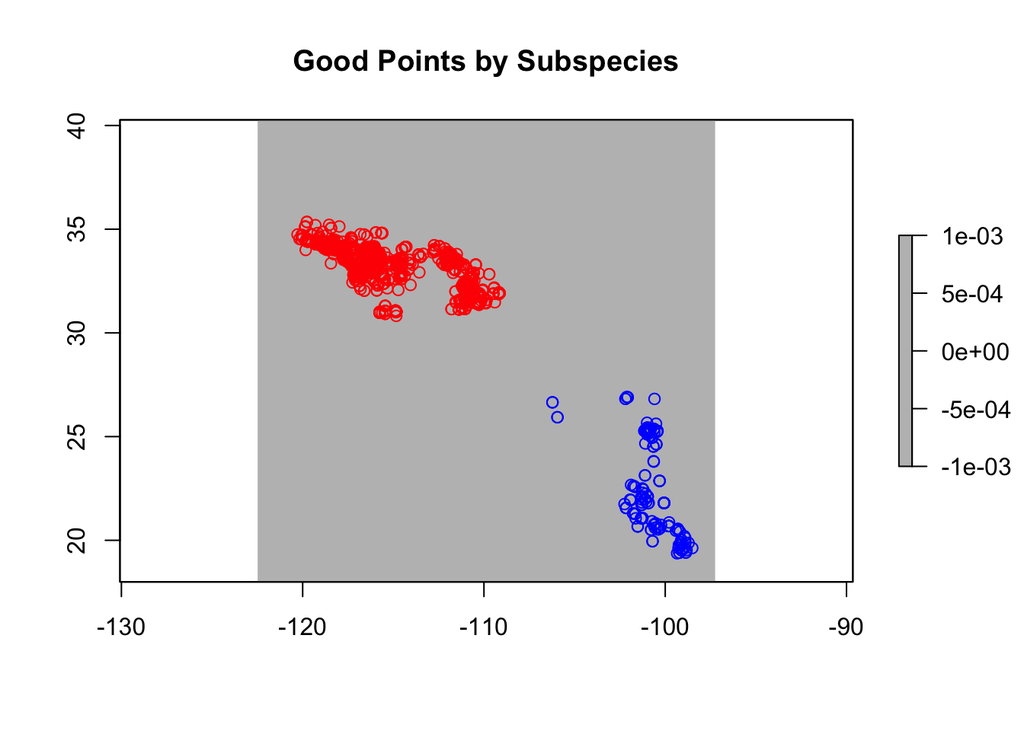

```r
raster::plot(
  bgLayer,
  col = "grey",
  colNA = "darkgrey",
  main = "Good Points by Subspecies"
)
points(loc_good$longitude,loc_good$latitude,col=as.numeric(as.factor(loc_good$assigned)))
```

Putting this all together in one function looks like this:

```
## [1] "Downloading species occurrences"
## [1] "Getting Species:  Phainopepla nitens"
## [1] "     Getting Subspecies:  lepida"
## [1] "     Getting Subspecies:  nitens"
## Searched: gbif
## Occurrences - Found: 545,712, Returned: 2,000
## Search type: Scientific
##   gbif: Phainopepla nitens (2000)
## $lepida
## Searched: gbif
## Occurrences - Found: 1,757, Returned: 1,757
## Search type: Scientific
##   gbif: Phainopepla nitens lepida (1757)
##
## $nitens
## Searched: gbif
## Occurrences - Found: 67, Returned: 67
## Search type: Scientific
##   gbif: Phainopepla nitens nitens (67)
##
## [1] "Labeling data by subspecies"
## [1] "lepida"
## [1] "nitens"
## [1] "Cleaning bad lat/longs"
## [1] "Rounding lat/longs to 2 decimal places"
## [1] "Removing points outside of bounds"
## [1] "RELABELING NOMINATE AFTER CLEANUP"
## [1] "Cleaning bgLayer"
## [1] "Starting anomaly detection for whole species"
## [1] "Starting anomaly detection for each subspecies"
## [1] "lepida"
## [1] 1757
## [1] 70
## [1] "nitens"
## [1] 67
## [1] 6
## [1] "Removing 76 of 3824 detected anomalies"
## [1] "Removing single-individual subspecies"
## [1] "Cleaning bgLayer 2nd time"
## [1] "Building species kernel density maps"
## [1] "unknown"
## [1] "rescaling"
```

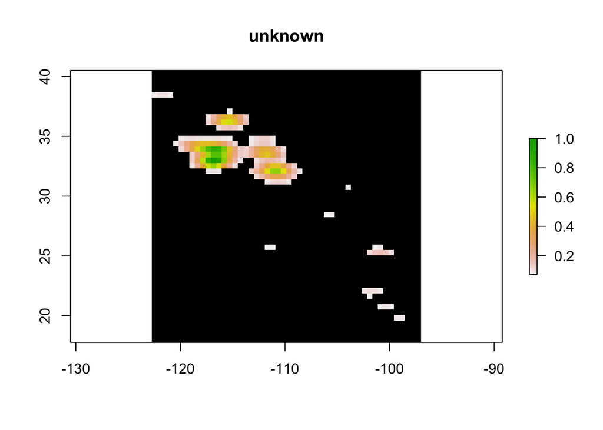

```
## [1] "lepida"
## [1] "rescaling"
```

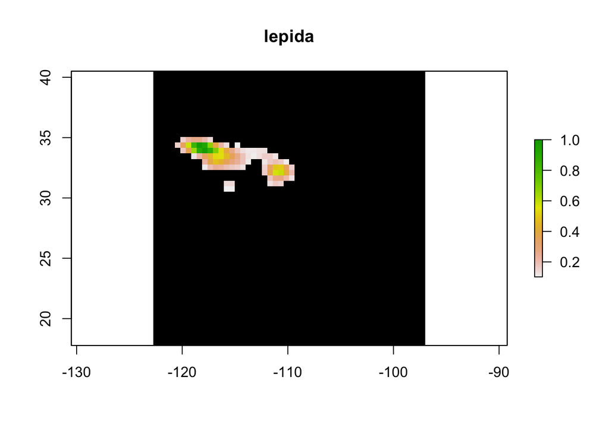

```
## [1] "nitens"
## [1] "rescaling"
```

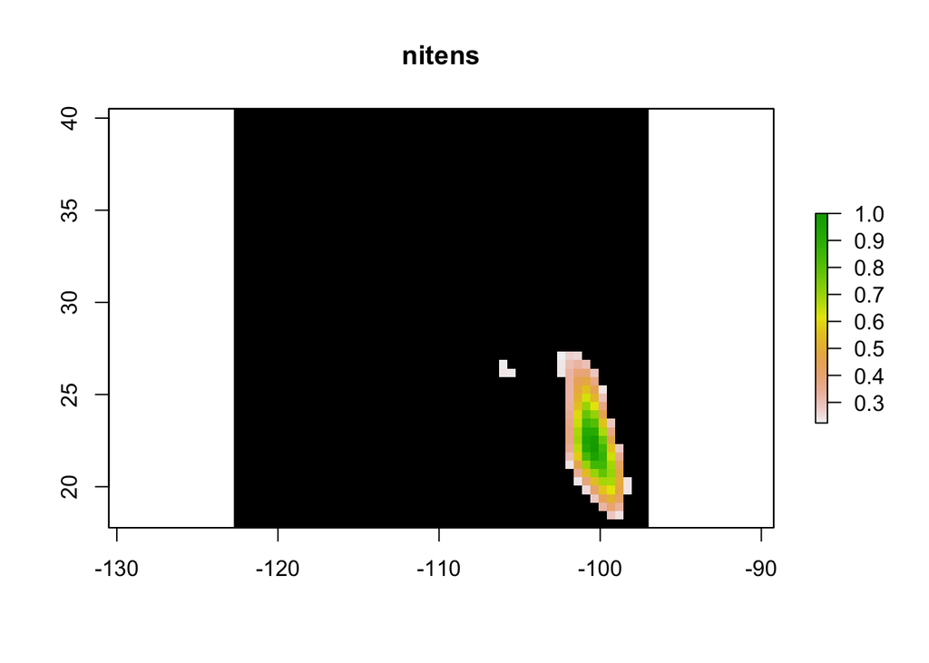

```
## [1] "Outputting density rasters"
## [1] "Removing overlapping raster sections from density map"
## [1] "Locating points relative to rasters"
## [1] "Cleaning up duplicate columns"
## [1] 9
## [1] "Matching subspecies"
## [1] 5
## [1] 6
## [1] "NONE ASSIGNED:"
## [1] "key"
## [1] 7
## [1] "NONE ASSIGNED:"
## [1] "subspecies"
## [1] 8
## [1] 9
## [1] "Warning: no valid definition for subspecies given!"
```

```r
db = subsppLabelR::createAssignedSubspecies(spp="Phainopepla nitens",
                                                subsppList = c("lepida","nitens"),
                                                pointLimit=2000,
                                                dbToQuery=c("gbif"),
                                                quant=0.90,
                                                xmin=-125,
                                                xmax=-60,
                                                ymin=10,
                                                ymax=50,
                                                plotIt=F, bgLayer=raster::raster(ext=raster::extent(c(xmin,xmax,ymin,ymax)),nrow=100,ncol=100,vals=0),
                                                outputDir="~/",
                                                spp_epsilon=1e-6,
                                                subspp_epsilon=10^-3.5,
                                                cells_per_bgLayer = 100)
```

```r
print(head(db$loc_suspect))
```

```
##                                   name longitude latitude prov       date
## 13 Phainopepla nitens (Swainson, 1838)   -105.50    28.38 gbif 2025-01-01
## 21 Phainopepla nitens (Swainson, 1838)   -115.43    36.15 gbif 2025-01-03
## 24 Phainopepla nitens (Swainson, 1838)   -111.98    26.89 gbif 2025-01-02
## 30 Phainopepla nitens (Swainson, 1838)   -111.34    26.00 gbif 2025-01-03
## 32 Phainopepla nitens (Swainson, 1838)   -102.54    22.78 gbif 2025-01-04
## 36 Phainopepla nitens (Swainson, 1838)   -111.89    34.77 gbif 2025-01-02
##           key subspecies lepida nitens numSubsppGroups assigned
## 13 5006878049    unknown      0      0               0     none
## 21 5007557666    unknown      0      0               0     none
## 24 5006774025    unknown      0      0               0     none
## 30 5008441763    unknown      0      0               0     none
## 32 5007249139    unknown      0      0               0     none
## 36 5007652839    unknown      0      0               0     none
```

```r
print(head(db$loc_good))
```

```
##                                  name longitude latitude prov       date
## 1 Phainopepla nitens (Swainson, 1838)   -117.88    34.04 gbif 2025-01-01
## 2 Phainopepla nitens (Swainson, 1838)   -118.13    34.20 gbif 2025-01-01
## 3 Phainopepla nitens (Swainson, 1838)   -116.39    33.70 gbif 2025-01-01
## 4 Phainopepla nitens (Swainson, 1838)   -117.18    34.06 gbif 2025-01-01
## 5 Phainopepla nitens (Swainson, 1838)   -117.09    32.55 gbif 2025-01-01
## 6 Phainopepla nitens (Swainson, 1838)   -118.42    34.04 gbif 2025-01-01
##          key subspecies lepida nitens numSubsppGroups assigned
## 1 5007745493    unknown      1      0               1   lepida
## 2 5007726941    unknown      1      0               1   lepida
## 3 5062944356    unknown      1      0               1   lepida
## 4 5007672481    unknown      1      0               1   lepida
## 5 5007257589    unknown      1      0               1   lepida
## 6 5007745594    unknown      1      0               1   lepida
```